# Kaggle project: House price regression

Xin (David) Zhao

Last edited 06 March 2023

## 0.1 Project aim

This is a Kaggle competition project. The purpose of this project is to predict house prices in Ames, Iowa from available variables with machine learning algorithms.

Personal learning purpose: - Reinforce machine learning knowledge - Practice using caret package and workflow - Learn advanced feature engineering - Learn new algorithms

## 0.2 Workflow

Follow the machine learning workflow of caret R package.

0. Load libraries
1. Import data
2. Exploratory data analysis
3. Preprocess data - Create dummy variables - Zero- and near zero-variance - Impute missing data - Label encoding - Drop highly correlated variables - Linear dependencies - Centering and scaling - Transform predictors - Remove outliers
4. Feature selection
5. Feature engineering*
6. Data splitting (skip)
7. Train and tune models - Lasso regression model - XGBoost model - Random forest
8. Evaluate performance

## 0.3 R code

### 0.3.1 Load R libraries

Load necessary libraries

```r
library(tidyverse)
library(caret)
library(factoextra) # visualize k-means
library(RANN)
library(mgcv) # generalized addictive model using splines - non-linear regression
library(ranger)  # random forest
library(h2o) # gradient boosting machines
library(WVPlots)  # draw gain curve plots
library(xgboost)  # eXtreme gradient boosting

library(devtools)
# install_github("cran/foba")
library(foba)
```

### 0.3.2 Import data sets

```r
# unzip downloaded file

unzip(zipfile = "./house-prices-advanced-regression-techniques.zip",
      files = NULL,
      exdir = "./raw-data")

list.files("./raw-data")
```

```
## [1] "data_description.txt"  "sample_submission.csv" "test.csv"
## [4] "train.csv"
```

The row datasets contain four files: - `data_description.txt` - `sample_submission.csv` - `test.csv` - `train.csv`

Import and inspect train set

```r
# read in train.csv

train_df <- read.csv(file = "./raw-data/train.csv",
                     header = T)

head(train_df)  # view first rows
```

|  | Id | MSSubClass | MSZoning | LotFrontage | LotArea | Street | Alley | LotShape | LandContour | Utilities | LotConfig | LandSlope | Neighborhood | Condition1 | Condition2 | BldgType | HouseStyle | OverallQual | OverallCond | YearBuilt | YearRemodAdd | RoofStyle | RoofMatl | Exterior1st | Exterior2nd | MasVnrType | MasVnrArea | ExterQual | ExterCond | … |
| --- | --- | --- | --- | --- | --- | --- | --- | --- | --- | --- | --- | --- | --- | --- | --- | --- | --- | --- | --- | --- | --- | --- | --- | --- | --- | --- | --- | --- | --- | --- |
| 1 | 1 | 60 | RL | 65 | 8450 | Pave | NA | Reg | Lvl | AllPub | Inside | Gtl | CollgCr | Norm | Norm | 1Fam | 2Story | 7 | 5 | 2003 | 2003 | Gable | CompShg | VinylSd | VinylSd | BrkFace | 196 | Gd | TA | … |
| 2 | 2 | 20 | RL | 80 | 9600 | Pave | NA | Reg | Lvl | AllPub | FR2 | Gtl | Veenker | Feedr | Norm | 1Fam | 1Story | 6 | 8 | 1976 | 1976 | Gable | CompShg | MetalSd | MetalSd | None | 0 | TA | TA | … |
| 3 | 3 | 60 | RL | 68 | 11250 | Pave | NA | IR1 | Lvl | AllPub | Inside | Gtl | CollgCr | Norm | Norm | 1Fam | 2Story | 7 | 5 | 2001 | 2002 | Gable | CompShg | VinylSd | VinylSd | BrkFace | 162 | Gd | TA | … |
| 4 | 4 | 70 | RL | 60 | 9550 | Pave | NA | IR1 | Lvl | AllPub | Corner | Gtl | Crawfor | Norm | Norm | 1Fam | 2Story | 7 | 5 | 1915 | 1970 | Gable | CompShg | Wd Sdng | Wd Shng | None | 0 | TA | TA | … |
| 5 | 5 | 60 | RL | 84 | 14260 | Pave | NA | IR1 | Lvl | AllPub | FR2 | Gtl | NoRidge | Norm | Norm | 1Fam | 2Story | 8 | 5 | 2000 | 2000 | Gable | CompShg | VinylSd | VinylSd | BrkFace | 350 | Gd | TA | … |
| 6 | 6 | 50 | RL | 85 | 14115 | Pave | NA | IR1 | Lvl | AllPub | Inside | Gtl | Mitchel | Norm | Norm | 1Fam | 1.5Fin | 5 | 5 | 1993 | 1995 | Gable | CompShg | VinylSd | VinylSd | None | 0 | TA | TA | … |

```r
# data structure
str(train_df)
```

```
## 'data.frame':    1460 obs. of  81 variables:
##  $ Id           : int  1 2 3 4 5 6 7 8 9 10 ...
##  $ MSSubClass   : int  60 20 60 70 60 50 20 60 50 190 ...
##  $ MSZoning     : chr  "RL" "RL" "RL" "RL" ...
##  $ LotFrontage  : int  65 80 68 60 84 85 75 NA 51 50 ...
##  $ LotArea      : int  8450 9600 11250 9550 14260 14115 10084 10382 6120 7420 ...
##  $ Street       : chr  "Pave" "Pave" "Pave" "Pave" ...
##  $ Alley        : chr  NA NA NA NA ...
##  $ LotShape     : chr  "Reg" "Reg" "IR1" "IR1" ...
##  $ LandContour  : chr  "Lvl" "Lvl" "Lvl" "Lvl" ...
##  $ Utilities    : chr  "AllPub" "AllPub" "AllPub" "AllPub" ...
##  $ LotConfig    : chr  "Inside" "FR2" "Inside" "Corner" ...
##  $ LandSlope    : chr  "Gtl" "Gtl" "Gtl" "Gtl" ...
##  $ Neighborhood : chr  "CollgCr" "Veenker" "CollgCr" "Crawfor" ...
##  $ Condition1   : chr  "Norm" "Feedr" "Norm" "Norm" ...
```

[output cut: 67 more lines]

```r
dim(train_df)
```

```
## [1] 1460   81
```

The train set contains 1460 observations and 81 variables.

Find description of response and explanatory variables at the Kaggle [website](https://www.kaggle.com/competitions/house-prices-advanced-regression-techniques/data).

Import and inspect test set

```r
# load test set
test_df <- read.csv(file = "./raw-data/test.csv",
                    header = T)

head(test_df) # view first rows
```

|  | Id | MSSubClass | MSZoning | LotFrontage | LotArea | Street | Alley | LotShape | LandContour | Utilities | LotConfig | LandSlope | Neighborhood | Condition1 | Condition2 | BldgType | HouseStyle | OverallQual | OverallCond | YearBuilt | YearRemodAdd | RoofStyle | RoofMatl | Exterior1st | Exterior2nd | MasVnrType | MasVnrArea | ExterQual | ExterCond | … |
| --- | --- | --- | --- | --- | --- | --- | --- | --- | --- | --- | --- | --- | --- | --- | --- | --- | --- | --- | --- | --- | --- | --- | --- | --- | --- | --- | --- | --- | --- | --- |
| 1 | 1461 | 20 | RH | 80 | 11622 | Pave | NA | Reg | Lvl | AllPub | Inside | Gtl | NAmes | Feedr | Norm | 1Fam | 1Story | 5 | 6 | 1961 | 1961 | Gable | CompShg | VinylSd | VinylSd | None | 0 | TA | TA | … |
| 2 | 1462 | 20 | RL | 81 | 14267 | Pave | NA | IR1 | Lvl | AllPub | Corner | Gtl | NAmes | Norm | Norm | 1Fam | 1Story | 6 | 6 | 1958 | 1958 | Hip | CompShg | Wd Sdng | Wd Sdng | BrkFace | 108 | TA | TA | … |
| 3 | 1463 | 60 | RL | 74 | 13830 | Pave | NA | IR1 | Lvl | AllPub | Inside | Gtl | Gilbert | Norm | Norm | 1Fam | 2Story | 5 | 5 | 1997 | 1998 | Gable | CompShg | VinylSd | VinylSd | None | 0 | TA | TA | … |
| 4 | 1464 | 60 | RL | 78 | 9978 | Pave | NA | IR1 | Lvl | AllPub | Inside | Gtl | Gilbert | Norm | Norm | 1Fam | 2Story | 6 | 6 | 1998 | 1998 | Gable | CompShg | VinylSd | VinylSd | BrkFace | 20 | TA | TA | … |
| 5 | 1465 | 120 | RL | 43 | 5005 | Pave | NA | IR1 | HLS | AllPub | Inside | Gtl | StoneBr | Norm | Norm | TwnhsE | 1Story | 8 | 5 | 1992 | 1992 | Gable | CompShg | HdBoard | HdBoard | None | 0 | Gd | TA | … |
| 6 | 1466 | 60 | RL | 75 | 10000 | Pave | NA | IR1 | Lvl | AllPub | Corner | Gtl | Gilbert | Norm | Norm | 1Fam | 2Story | 6 | 5 | 1993 | 1994 | Gable | CompShg | HdBoard | HdBoard | None | 0 | TA | TA | … |

The test set contains 1459 observations and 80 variables.

### 0.3.3 Exploratory data analysis

#### 0.3.3.1 Distribution of response variable in the train set

The target variable to predict is `SalePrice` - the property’s sale price in dollars.

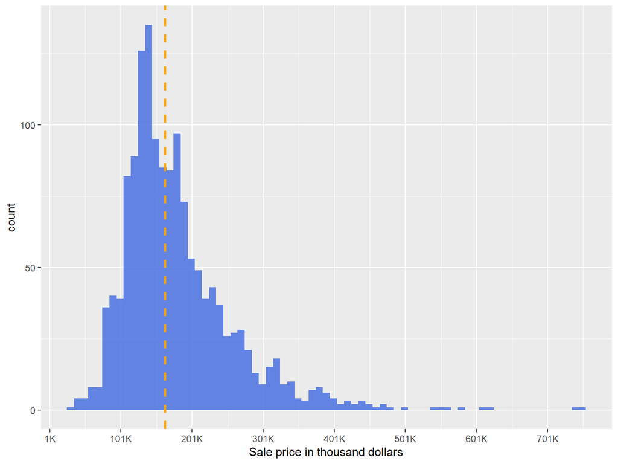

```r
# distribution of the response variable in the train set
ggplot(data = train_df, aes(x = SalePrice/1000)) +
        geom_histogram(binwidth = 10, fill = "royalblue", alpha = 0.8) +
        scale_x_continuous(name = "Sale price in thousand dollars",
                           breaks = seq(1, 800, by=100),
                           labels = paste(seq(1, 800, by=100), "K", sep = "")) +
        geom_vline(aes(xintercept = 163), linetype = "dashed", color = "orange", size = 1)
```

The dashed line in the above histogram indicates the median of the sale prices in the train set.

```r
# summary stats
summary(train_df$SalePrice) # median < mean
```

```
##    Min. 1st Qu.  Median    Mean 3rd Qu.    Max.
##   34900  129975  163000  180921  214000  755000
```

```r
# check if any missing values
sum(is.na(train_df$SalePrice))  # print 0
```

```
## [1] 0
```

### 0.3.4 Numeric and categorical variables

```r
# put Id column to row names in train set
train_df_id  <- train_df %>%
  mutate(Id = paste("W", Id, sep = "")) %>%  # add "W" next to Id
  column_to_rownames("Id")

dim(train_df_id)
```

```
## [1] 1460   80
```

```r
colnames_id <- colnames(train_df_id)
```

The train set has 79 independent variables plus one response variable for 1460 samples.

```r
# identify numeric variables and variables with >10 unique values
var_unique <- sapply(train_df_id, function(x) length(unique(x))) %>%
    as.data.frame()

var_factor <- sapply(train_df_id, function(x) is.character(x)) %>%
    as.data.frame() %>%
    rownames_to_column("variables")

var_types <- cbind(var_unique, var_factor)

# rename columns
colnames(var_types) <- c("unique_count", "variable", "is_char")

head(var_types)
```

|  | unique_count | variable | is_char |
| --- | --- | --- | --- |
| MSSubClass | 15 | MSSubClass | FALSE |
| MSZoning | 5 | MSZoning | TRUE |
| LotFrontage | 111 | LotFrontage | FALSE |
| LotArea | 1073 | LotArea | FALSE |
| Street | 2 | Street | TRUE |
| Alley | 3 | Alley | TRUE |

```r
var_types <- var_types %>%
  select(variable, unique_count, is_char)


# extract variables with unique values more than 10 & not categorical variables - numeric variables
is_num_var <- var_types %>%
  filter(unique_count >= 10 & is_char == 0) %>%
  pull(variable)

is_num_var
```

```
##  [1] "MSSubClass"    "LotFrontage"   "LotArea"       "OverallQual"
##  [5] "YearBuilt"     "YearRemodAdd"  "MasVnrArea"    "BsmtFinSF1"
##  [9] "BsmtFinSF2"    "BsmtUnfSF"     "TotalBsmtSF"   "X1stFlrSF"
## [13] "X2ndFlrSF"     "LowQualFinSF"  "GrLivArea"     "TotRmsAbvGrd"
## [17] "GarageYrBlt"   "GarageArea"    "WoodDeckSF"    "OpenPorchSF"
## [21] "EnclosedPorch" "X3SsnPorch"    "ScreenPorch"   "MiscVal"
## [25] "MoSold"        "SalePrice"
```

```r
is_num_var2 <- is_num_var[-which(is_num_var == "SalePrice")]  # exclude the response variable

is_num_var2
```

```
##  [1] "MSSubClass"    "LotFrontage"   "LotArea"       "OverallQual"
##  [5] "YearBuilt"     "YearRemodAdd"  "MasVnrArea"    "BsmtFinSF1"
##  [9] "BsmtFinSF2"    "BsmtUnfSF"     "TotalBsmtSF"   "X1stFlrSF"
## [13] "X2ndFlrSF"     "LowQualFinSF"  "GrLivArea"     "TotRmsAbvGrd"
## [17] "GarageYrBlt"   "GarageArea"    "WoodDeckSF"    "OpenPorchSF"
## [21] "EnclosedPorch" "X3SsnPorch"    "ScreenPorch"   "MiscVal"
## [25] "MoSold"
```

25 numeric variables other than the response variable `SalePrice`.

```r
# identify categorical variables with no more than 10 unique values or is_character true
is_fact_var <- var_types %>%
  filter(unique_count < 10 | is_char == 1) %>%
  pull(variable)

is_fact_var   # view variable names
```

```
##  [1] "MSZoning"      "Street"        "Alley"         "LotShape"
##  [5] "LandContour"   "Utilities"     "LotConfig"     "LandSlope"
##  [9] "Neighborhood"  "Condition1"    "Condition2"    "BldgType"
## [13] "HouseStyle"    "OverallCond"   "RoofStyle"     "RoofMatl"
## [17] "Exterior1st"   "Exterior2nd"   "MasVnrType"    "ExterQual"
## [21] "ExterCond"     "Foundation"    "BsmtQual"      "BsmtCond"
## [25] "BsmtExposure"  "BsmtFinType1"  "BsmtFinType2"  "Heating"
## [29] "HeatingQC"     "CentralAir"    "Electrical"    "BsmtFullBath"
## [33] "BsmtHalfBath"  "FullBath"      "HalfBath"      "BedroomAbvGr"
## [37] "KitchenAbvGr"  "KitchenQual"   "Functional"    "Fireplaces"
## [41] "FireplaceQu"   "GarageType"    "GarageFinish"  "GarageCars"
## [45] "GarageQual"    "GarageCond"    "PavedDrive"    "PoolArea"
## [49] "PoolQC"        "Fence"         "MiscFeature"   "YrSold"
## [53] "SaleType"      "SaleCondition"
```

```r
length(is_fact_var) # print 54
```

```
## [1] 54
```

```r
# check if any variable left
colnames_id[-which(colnames_id %in% c(is_num_var2, is_fact_var))]
```

```
## [1] "SalePrice"
```

Scatter plots to show relationship between numeric variables and the response variable, `SalePrice`

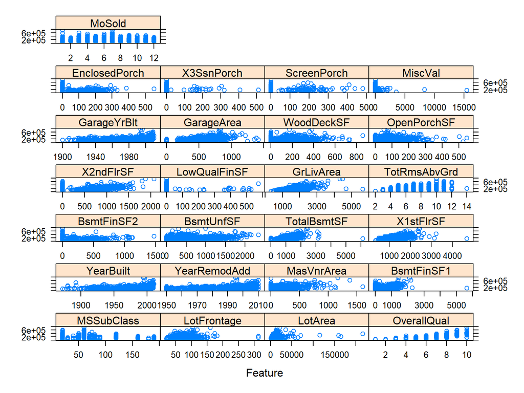

```r
caret::featurePlot(x = train_df_id[ ,is_num_var2],  # 24 numeric variables
                   y = train_df_id$SalePrice,
                   plot = "Scatter",
                   layout = c(4,7))
```

Investigate description statistics of independent numeric variables.

```r
# investigate mean, median and NA in numeric variables including SalePrice
summary(train_df_id[ ,is_num_var])
```

```
##    MSSubClass     LotFrontage        LotArea        OverallQual
##  Min.   : 20.0   Min.   : 21.00   Min.   :  1300   Min.   : 1.000
##  1st Qu.: 20.0   1st Qu.: 59.00   1st Qu.:  7554   1st Qu.: 5.000
##  Median : 50.0   Median : 69.00   Median :  9478   Median : 6.000
##  Mean   : 56.9   Mean   : 70.05   Mean   : 10517   Mean   : 6.099
##  3rd Qu.: 70.0   3rd Qu.: 80.00   3rd Qu.: 11602   3rd Qu.: 7.000
##  Max.   :190.0   Max.   :313.00   Max.   :215245   Max.   :10.000
##                  NA's   :259
##    YearBuilt     YearRemodAdd    MasVnrArea       BsmtFinSF1
##  Min.   :1872   Min.   :1950   Min.   :   0.0   Min.   :   0.0
##  1st Qu.:1954   1st Qu.:1967   1st Qu.:   0.0   1st Qu.:   0.0
##  Median :1973   Median :1994   Median :   0.0   Median : 383.5
##  Mean   :1971   Mean   :1985   Mean   : 103.7   Mean   : 443.6
##  3rd Qu.:2000   3rd Qu.:2004   3rd Qu.: 166.0   3rd Qu.: 712.2
##  Max.   :2010   Max.   :2010   Max.   :1600.0   Max.   :5644.0
##                                NA's   :8
##    BsmtFinSF2        BsmtUnfSF       TotalBsmtSF       X1stFlrSF
##  Min.   :   0.00   Min.   :   0.0   Min.   :   0.0   Min.   : 334
##  1st Qu.:   0.00   1st Qu.: 223.0   1st Qu.: 795.8   1st Qu.: 882
##  Median :   0.00   Median : 477.5   Median : 991.5   Median :1087
##  Mean   :  46.55   Mean   : 567.2   Mean   :1057.4   Mean   :1163
##  3rd Qu.:   0.00   3rd Qu.: 808.0   3rd Qu.:1298.2   3rd Qu.:1391
##  Max.   :1474.00   Max.   :2336.0   Max.   :6110.0   Max.   :4692
##
##    X2ndFlrSF     LowQualFinSF       GrLivArea     TotRmsAbvGrd
##  Min.   :   0   Min.   :  0.000   Min.   : 334   Min.   : 2.000
##  1st Qu.:   0   1st Qu.:  0.000   1st Qu.:1130   1st Qu.: 5.000
##  Median :   0   Median :  0.000   Median :1464   Median : 6.000
##  Mean   : 347   Mean   :  5.845   Mean   :1515   Mean   : 6.518
##  3rd Qu.: 728   3rd Qu.:  0.000   3rd Qu.:1777   3rd Qu.: 7.000
##  Max.   :2065   Max.   :572.000   Max.   :5642   Max.   :14.000
##
##   GarageYrBlt     GarageArea       WoodDeckSF      OpenPorchSF
##  Min.   :1900   Min.   :   0.0   Min.   :  0.00   Min.   :  0.00
##  1st Qu.:1961   1st Qu.: 334.5   1st Qu.:  0.00   1st Qu.:  0.00
##  Median :1980   Median : 480.0   Median :  0.00   Median : 25.00
##  Mean   :1979   Mean   : 473.0   Mean   : 94.24   Mean   : 46.66
##  3rd Qu.:2002   3rd Qu.: 576.0   3rd Qu.:168.00   3rd Qu.: 68.00
##  Max.   :2010   Max.   :1418.0   Max.   :857.00   Max.   :547.00
##  NA's   :81
##  EnclosedPorch      X3SsnPorch      ScreenPorch        MiscVal
##  Min.   :  0.00   Min.   :  0.00   Min.   :  0.00   Min.   :    0.00
##  1st Qu.:  0.00   1st Qu.:  0.00   1st Qu.:  0.00   1st Qu.:    0.00
##  Median :  0.00   Median :  0.00   Median :  0.00   Median :    0.00
##  Mean   : 21.95   Mean   :  3.41   Mean   : 15.06   Mean   :   43.49
##  3rd Qu.:  0.00   3rd Qu.:  0.00   3rd Qu.:  0.00   3rd Qu.:    0.00
##  Max.   :552.00   Max.   :508.00   Max.   :480.00   Max.   :15500.00
##
##      MoSold         SalePrice
##  Min.   : 1.000   Min.   : 34900
##  1st Qu.: 5.000   1st Qu.:129975
##  Median : 6.000   Median :163000
##  Mean   : 6.322   Mean   :180921
##  3rd Qu.: 8.000   3rd Qu.:214000
##  Max.   :12.000   Max.   :755000
##
```

Highly skewed (substantial difference between median and mean) independent numeric variables: `MasVnrArea` `BsmtFinSF2` `X2ndFlrSF` `LowQualFinSF` `WoodDeckSF` `EnclosedPorch` `X3SsnPorch` `ScreenPorch` `MiscVal`

Numeric variables have NAs: `LotFrontage` `MasVnrArea` `GarageYrBlt`

### 0.3.5 Categrorical variables - EDA

```r
# covert character variables to factors
train_df_fact  <- train_df_id %>%
  dplyr::select(all_of(is_fact_var)) %>%   # subset 54 non-numeric variables and a response variable
  mutate_all(., as.factor)  %>% # convert character variables to factors
  bind_cols(., SalePrice = train_df_id$SalePrice)   # bind columns

# structure of the resulting data frame
str(train_df_fact)
```

```
## 'data.frame':    1460 obs. of  55 variables:
##  $ MSZoning     : Factor w/ 5 levels "C (all)","FV",..: 4 4 4 4 4 4 4 4 5 4 ...
##  $ Street       : Factor w/ 2 levels "Grvl","Pave": 2 2 2 2 2 2 2 2 2 2 ...
##  $ Alley        : Factor w/ 2 levels "Grvl","Pave": NA NA NA NA NA NA NA NA NA NA ...
##  $ LotShape     : Factor w/ 4 levels "IR1","IR2","IR3",..: 4 4 1 1 1 1 4 1 4 4 ...
##  $ LandContour  : Factor w/ 4 levels "Bnk","HLS","Low",..: 4 4 4 4 4 4 4 4 4 4 ...
##  $ Utilities    : Factor w/ 2 levels "AllPub","NoSeWa": 1 1 1 1 1 1 1 1 1 1 ...
##  $ LotConfig    : Factor w/ 5 levels "Corner","CulDSac",..: 5 3 5 1 3 5 5 1 5 1 ...
##  $ LandSlope    : Factor w/ 3 levels "Gtl","Mod","Sev": 1 1 1 1 1 1 1 1 1 1 ...
##  $ Neighborhood : Factor w/ 25 levels "Blmngtn","Blueste",..: 6 25 6 7 14 12 21 17 18 4 ...
##  $ Condition1   : Factor w/ 9 levels "Artery","Feedr",..: 3 2 3 3 3 3 3 5 1 1 ...
##  $ Condition2   : Factor w/ 8 levels "Artery","Feedr",..: 3 3 3 3 3 3 3 3 3 1 ...
##  $ BldgType     : Factor w/ 5 levels "1Fam","2fmCon",..: 1 1 1 1 1 1 1 1 1 2 ...
##  $ HouseStyle   : Factor w/ 8 levels "1.5Fin","1.5Unf",..: 6 3 6 6 6 1 3 6 1 2 ...
##  $ OverallCond  : Factor w/ 9 levels "1","2","3","4",..: 5 8 5 5 5 5 5 6 5 6 ...
```

[output cut: 41 more lines]

Subset 54 independent factors and the response variable `SalePrice` following by correlation analysis.

### 0.3.6 Relationship between factors and the response variable

#### 0.3.6.1 Binary factors

Identify top factor variables associated with `SalePrice`. Use non-parameter [Kruskal-Wallis test](https://en.wikipedia.org/wiki/Kruskal%E2%80%93Wallis_one-way_analysis_of_variance#:~:text=Allen%20Wallis)%2C%20or%20one%2D,for%20comparing%20only%20two%20groups.) for multiple-class variables, while using [Mann-Whitney U test](https://en.wikipedia.org/wiki/Mann%E2%80%93Whitney_U_test) to binary-class variables.

Use purrr package to apply function to columns of the data frame, referring to the [instruction](https://rpubs.com/faiazrmn/purrr_map_map2)

```r
# extract binary variables
is_binary <- train_df_fact %>%
        purrr::map_dfr(\(train_df_fact) length(levels(train_df_fact))) %>%
        gather(key = "factor_variable", value = "levels") %>%
        filter(levels == 2) %>%
        pull(factor_variable)

length(is_binary) # print 4
```

```
## [1] 4
```

```r
# apply Wilcox test to each variables
train_df_fact_l2 <- train_df_fact %>%
        select(all_of(is_binary), SalePrice)

response_var <- train_df_fact_l2$SalePrice %>% as.data.frame()

binary_var <- train_df_fact_l2 %>% select(-SalePrice)

wilcox_fact_lv2 <- map2(binary_var, response_var, ~wilcox.test(.y ~ .x))


# extract p-value and significant factors
wilcox_fact_lv2_df <- do.call(rbind, wilcox_fact_lv2) %>%
        as.data.frame() %>%
        rownames_to_column("variable") %>%
        select(variable, p.value) %>%
        filter(p.value <= 0.05) %>%
        pull(variable)

wilcox_fact_lv2_df # significant variable names
```

```
## [1] "Alley"      "CentralAir"
```

Among the binary factors, `Alley` and `CentralAir` are significantly associated with the response variable.

#### 0.3.6.2 Multi-class factors

```r
# extract multi-class variables
is_multiclass <- train_df_fact %>%
        purrr::map_dfr(\(train_df_fact) length(levels(train_df_fact))) %>%
        gather(key = "factor_variable", value = "levels") %>%
        filter(levels > 2) %>%
        pull(factor_variable)

length(is_multiclass)  # print 50
```

```
## [1] 50
```

```r
# apply kruskal-wallis test to each variables
train_df_fact_multi <- train_df_fact %>%
        select(all_of(is_multiclass), SalePrice)

response_var <- train_df_fact_multi$SalePrice  %>% as.data.frame()

multiclass_var <- train_df_fact_multi %>% select(-SalePrice)

wilcox_fact_multi <- map2(multiclass_var, response_var, ~kruskal.test(.y ~ .x))

# extract p-value and significant variables
wilcox_fact_multi_df <- do.call(rbind, wilcox_fact_multi) %>%
        as.data.frame() %>%
        rownames_to_column("variable") %>%
        select(variable, p.value) %>%
        filter(p.value <= 0.05) %>%
        pull(variable)

length(wilcox_fact_multi_df)  # 43 variables significant
```

```
## [1] 43
```

Summarize statistical results from correlation analysis between factors and the response variable, `SalePrice`.

```r
# combine significant factors names, binary and multi-class
sig_factors <- c(wilcox_fact_lv2_df, wilcox_fact_multi_df)

length(sig_factors)  # 45 significant factors in total
```

```
## [1] 45
```

```r
# summary
factor_sig_overall <- train_df_fact %>%
  purrr::map_dfr(\(train_df_fact) length(levels(train_df_fact))) %>%
  gather(key = "factor_variable", value = "levels") %>%
  mutate(is_significant = case_when(factor_variable %in% sig_factors == 1 ~ "yes",
                            factor_variable %in% sig_factors == 0 ~ "no"))  %>%
  mutate(is_significant = as.factor(is_significant))

# factor_sig_overall # print the resulting data frame
factor_sig_overall %>%
  count(levels, sort = T)
```

| levels | n |
| --- | --- |
| 4 | 14 |
| 5 | 11 |
| 6 | 7 |
| 3 | 6 |
| 8 | 5 |
| 2 | 4 |
| 9 | 3 |
| 0 | 1 |
| 7 | 1 |
| 15 | 1 |

[output cut: 2 more lines]

```r
# factor with 15 classes
factor_sig_overall %>%
  filter(levels == 15)
```

| factor_variable | levels | is_significant |
| --- | --- | --- |
| Exterior1st | 15 | yes |

In the table, `levels` represents class numbers of the factors. Majority factors have 4-5 classes. `Exterior1st` has 15 unique classes.

### 0.3.7 Dummy variable

Use `dummyVars` function in `caret` package to generate a complete set of dummy variables from multiple factors.

```r
# subset significant factors from train set

# train_df_fact_sig <- train_df_fact %>%
#         select(all_of(wilcox_fact_lv2_df),
#                all_of(wilcox_fact_multi_df),
#                SalePrice)
#
#
# dim(train_df_fact_sig)


# subset numeric variables
train_df_num <- train_df_id[ ,is_num_var2]

# combine numeric variables and factors
train_df2 <- cbind(train_df_fact, train_df_num)
```

The function `model.matrix` creates a design (or model) matrix. [R documentation](https://www.rdocumentation.org/packages/stats/versions/3.6.2/topics/model.matrix) provides detailed information regarding the function.

```r
# head(model.matrix(SalePrice ~., data = train_df_fact_sig))
dummies_train <- dummyVars(~., data = train_df2,
                           fullRank = TRUE,
                           sep = "_")
dummies_train
```

```
## Dummy Variable Object
##
## Formula: ~.
## <environment: 0x000001dbbc1c76f8>
## 80 variables, 54 factors
## Variables and levels will be separated by '_'
## A full rank encoding is used
```

```r
dummies_train_df <- data.frame(predict(dummies_train, newdata = train_df2))


dim(train_df2)  # 80 variables
```

```
## [1] 1460   80
```

```r
dim(dummies_train_df)  # resulting train set with 281 variables
```

```
## [1] 1460  281
```

### 0.3.8 Near-zero variance

According to the caret package documentation, a variable is considered the near-zero variance when it meets the conditions as follows,

- “frequency ratio” is greater than a pre-specified threshold
- “unique value percentage” is less than a threshold

The [website](https://topepo.github.io/caret/pre-processing.html#creating-dummy-variables) provide detailed explanation regarding near-zero variance.

Identify zero- and near-zero variance variables, or either.

```r
# near-zero variance
nzv <- nearZeroVar(dummies_train_df, saveMetrics = F)

# drop nzv variables
dummies_train_nzv <- dummies_train_df[,-nzv]

dim(dummies_train_df)  # 281 variables
```

```
## [1] 1460  281
```

```r
dim(dummies_train_nzv)  # 118 variables
```

```
## [1] 1460  118
```

### 0.3.9 Highly correlated variables

```r
fl_train_cor <- cor(dummies_train_nzv) # pairwise correlation

# summary(fl_train_cor[upper.tri(fl_train_cor)]) # upper triangle of correlations matrix before the removal

# replace NA with 0
fl_train_cor2 <- fl_train_cor %>% replace(is.na(.), 0)

# index of highly correlated variables
highcorvar <- caret::findCorrelation(fl_train_cor2, cutoff = .75)

highcorvar2 <- highcorvar[highcorvar != which(colnames(dummies_train_nzv) == "SalePrice")]

# remove the highly correlated variables in the train set
dummies_train_nzv2 <- dummies_train_nzv %>%
        select(!all_of(highcorvar2))  # drop highly correlated variables

dim(dummies_train_nzv2)  # 100 variables in the resulting train set
## [1] 1460  100
```

### 0.3.10 Imuptation

Caret package tutorial introduces two methods to impute missing values, K-nearest neighbors and bagged trees.

The caret website provides detailed explanation.

```r
# distribution of missing values in data
miss_value <- sapply(dummies_train_nzv2, function(x) mean(is.na(x))) %>% as.data.frame()

colnames(miss_value) <- "missing_percent"

miss_value2 <- miss_value %>%
  rownames_to_column("variable") %>%
  mutate(missing_percent = round(missing_percent, 2)) %>%
  arrange(desc(missing_percent))

# NA in independent variables in the train set
miss_value2
```

| variable | missing_percent |
| --- | --- |
| PoolQC_Fa | 1.00 |
| PoolQC_Gd | 1.00 |
| MiscFeature_Shed | 0.96 |
| Alley_Pave | 0.94 |
| Fence_GdWo | 0.81 |
| Fence_MnPrv | 0.81 |
| FireplaceQu_Gd | 0.47 |
| FireplaceQu_TA | 0.47 |
| LotFrontage | 0.18 |
| GarageType_Attchd | 0.06 |

[output cut: 90 more lines]

```r
# top variables with NA
top10_var_missing <- miss_value2 %>%
  filter(missing_percent > 0.4) %>%
  pull(variable)


# drop variables with substantial missing values
dummies_train_missing <- dummies_train_nzv2 %>%
  select(-all_of(top10_var_missing))

dim(dummies_train_missing)  # 92 variables left in the resulting train set
```

```
## [1] 1460   92
```

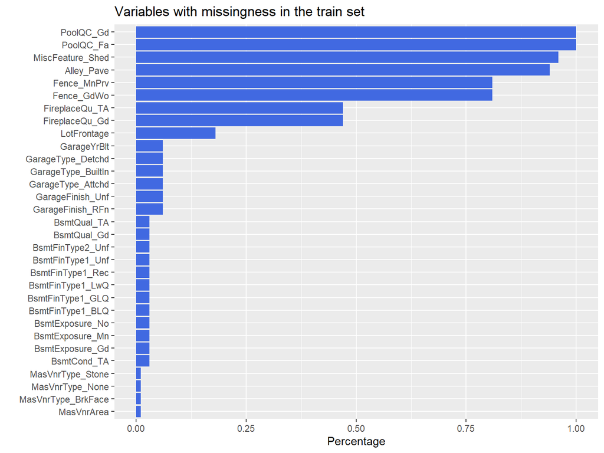

```r
# ggplot bar plot for variables with missingness
miss_value2 %>%
  filter(missing_percent != 0) %>%
  ggplot(aes(x = reorder(variable, missing_percent),  # reorder variable by missing percentages
           y= missing_percent)) +
  geom_bar(stat = "identity", fill = "royalblue") +
  coord_flip() +
  ggtitle("Variables with missingness in the train set") +
  labs(y ="Percentage", x= "")
```

```r
# # apply k-nearest method to impute data
# impute_knn <- preProcess(dummies_train_missing,
#                          method = "knnImpute")
#
# impute_knn
#
#
# # train set after KNN imputation
# dummies_train_impute <- predict(impute_knn, newdata = dummies_train_missing)


# I encountered an error when running the KNN impute method. I found a Stack Exchange post said that "the problem you run into is that knnImpute requires at least as many samples in your data without missing values as you have specified with the k parameter for the k-nearest-neighbors."
```

### 0.3.11 Feature selection

The [tutorial](https://topepo.github.io/caret/feature-selection-using-univariate-filters.html) of caret package provides an overview of various methods for feature selection: - Wrapper - recursive feature elimination - genetic algorithms - simulated annealing - Filter - univariate filters

#### 0.3.11.1 Feature selection - PCA

Conduct k-means clustering analysis on the filtered variables in the train set. Refer to instructions on Datacamp and the website, [Datanovia](https://www.datanovia.com/en/lessons/k-means-clustering-in-r-algorith-and-practical-examples/).

```r
# # replace NA with 0
# dummies_train_nzv3 <- dummies_train_impute %>% replace(is.na(.), 0)
#
# # scale
# dummies_train_nzv3_scale <- scale(dummies_train_impute)
#
#
#
# # implement k-means
# set.seed(123)
#
# kmeans_train <- kmeans(dummies_train_nzv3_scale,
#                        centers = 3,  # group the data into 3 clusters
#                        nstart = 20)  # generate 20 initial configuration
#
# summary(kmeans_train)
#
#
# # distribution of k-means clustering
# table(kmeans_train$cluster)
#
#
# # # calculate mean of the response variable, SalePrice by the clusters
# # aggregate(dummies_train_nzv,
# #           by = list(cluster = kmeans_train$cluster),
# #           mean) %>%
# #         select(cluster, SalePrice)
```

Visualize kmeans clustering with `fviz_cluster` function in `functoextra` package. Refer to the online [instruction](https://uc-r.github.io/kmeans_clustering)

```r
# fviz_cluster(kmeans_train,
#              data = dummies_train_nzv3_scale,
#              geom= "point")
```

Determine optimal cluster with the Elbow plot. Refer to the online [codes](https://uc-r.github.io/kmeans_clustering#elbow)

```r
# set.seed(123)
#
# # function to compute total within-cluster sum of square
# wss <- function(k) {
#   kmeans(dummies_train_nzv3_scale, k, nstart = 10 )$tot.withinss
# }
#
# # Compute and plot wss for k = 1 to k = 15
# k.values <- 1:15
#
# # extract wss for 2-15 clusters
# wss_values <- map_dbl(k.values, wss)
#
# plot(k.values, wss_values,
#        type="b", pch = 19, frame = FALSE,
#        xlab="Number of clusters K",
#        ylab="Total within-clusters sum of squares")
```

Run PCA on the filtered variables in the train-set.

```r
set.seed(123)

train_pca_rm.na <- dummies_train_missing %>% replace(is.na(.), 0) # replace NA with 0

pr.train <- prcomp(x = train_pca_rm.na, scale =T, center = T)

summary(pr.train)
```

```
## Importance of components:
##                           PC1     PC2     PC3     PC4     PC5     PC6     PC7
## Standard deviation     3.4634 2.19710 1.93812 1.79587 1.67828 1.59307 1.46132
## Proportion of Variance 0.1304 0.05247 0.04083 0.03506 0.03062 0.02759 0.02321
## Cumulative Proportion  0.1304 0.18285 0.22368 0.25874 0.28935 0.31694 0.34015
##                            PC8     PC9    PC10    PC11    PC12    PC13    PC14
## Standard deviation     1.42563 1.34656 1.32872 1.30010 1.27713 1.24916 1.23625
## Proportion of Variance 0.02209 0.01971 0.01919 0.01837 0.01773 0.01696 0.01661
## Cumulative Proportion  0.36224 0.38195 0.40114 0.41951 0.43724 0.45420 0.47081
##                           PC15    PC16    PC17    PC18    PC19    PC20    PC21
## Standard deviation     1.23115 1.21940 1.18732 1.15643 1.14498 1.12953 1.11731
## Proportion of Variance 0.01648 0.01616 0.01532 0.01454 0.01425 0.01387 0.01357
## Cumulative Proportion  0.48729 0.50345 0.51877 0.53331 0.54756 0.56143 0.57500
##                           PC22    PC23    PC24    PC25   PC26    PC27    PC28
## Standard deviation     1.11107 1.09656 1.09078 1.06732 1.0595 1.04986 1.03665
## Proportion of Variance 0.01342 0.01307 0.01293 0.01238 0.0122 0.01198 0.01168
## Cumulative Proportion  0.58841 0.60148 0.61442 0.62680 0.6390 0.65098 0.66266
##                           PC29    PC30    PC31    PC32   PC33    PC34   PC35
## Standard deviation     1.02165 1.01729 1.00984 0.98872 0.9783 0.97496 0.9641
## Proportion of Variance 0.01135 0.01125 0.01108 0.01063 0.0104 0.01033 0.0101
## Cumulative Proportion  0.67401 0.68526 0.69634 0.70697 0.7174 0.72770 0.7378
##                           PC36    PC37    PC38    PC39    PC40    PC41    PC42
## Standard deviation     0.94180 0.92764 0.91767 0.90222 0.89366 0.88286 0.87984
## Proportion of Variance 0.00964 0.00935 0.00915 0.00885 0.00868 0.00847 0.00841
## Cumulative Proportion  0.74745 0.75680 0.76595 0.77480 0.78348 0.79196 0.80037
##                           PC43    PC44    PC45    PC46    PC47    PC48    PC49
## Standard deviation     0.87345 0.85383 0.84500 0.84211 0.83220 0.82310 0.80722
## Proportion of Variance 0.00829 0.00792 0.00776 0.00771 0.00753 0.00736 0.00708
## Cumulative Proportion  0.80866 0.81659 0.82435 0.83206 0.83958 0.84695 0.85403
##                           PC50    PC51    PC52    PC53    PC54    PC55    PC56
## Standard deviation     0.80199 0.78430 0.77773 0.76185 0.74675 0.74138 0.73885
## Proportion of Variance 0.00699 0.00669 0.00657 0.00631 0.00606 0.00597 0.00593
## Cumulative Proportion  0.86102 0.86771 0.87428 0.88059 0.88665 0.89263 0.89856
##                           PC57    PC58    PC59    PC60    PC61    PC62   PC63
## Standard deviation     0.73509 0.71079 0.70732 0.69469 0.66379 0.65511 0.6433
## Proportion of Variance 0.00587 0.00549 0.00544 0.00525 0.00479 0.00466 0.0045
## Cumulative Proportion  0.90443 0.90993 0.91536 0.92061 0.92540 0.93006 0.9346
##                           PC64    PC65    PC66    PC67    PC68    PC69    PC70
## Standard deviation     0.63757 0.61685 0.60428 0.60064 0.59793 0.57645 0.56034
## Proportion of Variance 0.00442 0.00414 0.00397 0.00392 0.00389 0.00361 0.00341
## Cumulative Proportion  0.93898 0.94312 0.94708 0.95101 0.95489 0.95850 0.96192
##                           PC71   PC72    PC73    PC74    PC75    PC76    PC77
## Standard deviation     0.55362 0.5422 0.52221 0.50371 0.49219 0.48173 0.47041
## Proportion of Variance 0.00333 0.0032 0.00296 0.00276 0.00263 0.00252 0.00241
## Cumulative Proportion  0.96525 0.9684 0.97141 0.97417 0.97680 0.97932 0.98173
##                           PC78    PC79    PC80    PC81    PC82    PC83    PC84
## Standard deviation     0.46771 0.44034 0.42015 0.40174 0.38526 0.37848 0.35781
## Proportion of Variance 0.00238 0.00211 0.00192 0.00175 0.00161 0.00156 0.00139
## Cumulative Proportion  0.98410 0.98621 0.98813 0.98988 0.99150 0.99306 0.99445
##                           PC85    PC86    PC87    PC88    PC89    PC90    PC91
## Standard deviation     0.32619 0.32374 0.31099 0.27457 0.25003 0.18473 0.16127
## Proportion of Variance 0.00116 0.00114 0.00105 0.00082 0.00068 0.00037 0.00028
## Cumulative Proportion  0.99560 0.99674 0.99779 0.99861 0.99929 0.99966 0.99995
##                           PC92
## Standard deviation     0.07040
## Proportion of Variance 0.00005
## Cumulative Proportion  1.00000
```

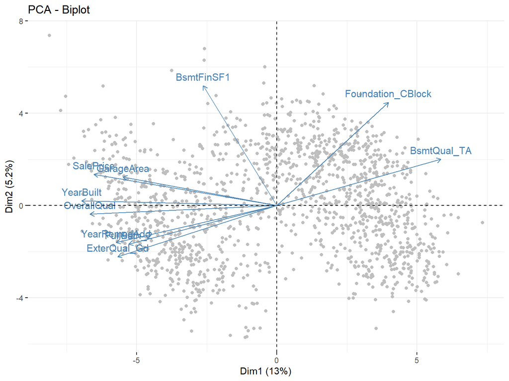

```r
# # ggplot2-based plot for PCA analysis
fviz_pca_biplot(pr.train,
                repel = F,
                col.ind = "grey",
                label = "var",
                select.var = list(contrib = 10)) # show top 10 variables
```

Extract loading from PCA analysis using `factoextra` package.

```r
# # extract contribution of variables
pca_var <- factoextra::get_pca_var(pr.train)

# top 10 variables that explain variations of data
top_var_pca <- pca_var$contrib  %>%
  as.data.frame() %>%
  arrange(desc(abs(Dim.1))) %>%
  rownames_to_column("Variable") %>%
  head(12) %>%
  pull(Variable)

top_var_pca
```

```
##  [1] "YearBuilt"        "OverallQual"      "SalePrice"        "BsmtQual_TA"
##  [5] "YearRemodAdd"     "ExterQual_Gd"     "GarageArea"       "FullBath_2"
##  [9] "GarageFinish_Unf" "OverallCond_5"    "GarageCars_1"     "BsmtQual_Gd"
```

#### 0.3.11.2 Feature selection - univariate analysis

```r
# pair-wise correlation among 90 variables
res_num <- cor(dummies_train_missing)  # pearson correlation method

colnames(res_num) <- 1:ncol(res_num)

# extract index for significant variables
top_num_index <- res_num %>%
        as.data.frame() %>%
        rownames_to_column("variable") %>%
        mutate(row_index = 1:nrow(.)) %>%
        gather(key = "col_index", value = "rho", -c("row_index", "variable")) %>%
        filter(variable == "SalePrice") %>%
        filter(abs(rho) >= 0.4) %>%
        arrange(desc(abs(rho))) %>%
        pull(col_index) %>%
        as.numeric()

top_univar <- rownames(res_num)[top_num_index]  # top variable names

top_univar
```

```
##  [1] "SalePrice"            "OverallQual"          "GarageArea"
##  [4] "GarageCars_3"         "X1stFlrSF"            "TotRmsAbvGrd"
##  [7] "YearBuilt"            "YearRemodAdd"         "ExterQual_Gd"
## [10] "FullBath_2"           "Neighborhood_NridgHt"
```

Alternatively, use `sbf` function in the `caret` package to implement univariate filtering. Follow the code example in the caret [tutorial](https://topepo.github.io/caret/feature-selection-using-univariate-filters.html).

```r
filterCtrl <- sbfControl(functions = rfSBF,
                         method = "repeatedcv",
                         repeats = 5)

set.seed(123)

predictors <- dummies_train_missing %>%  select(-SalePrice) %>% replace(is.na(.), 0)

rfWithinFilter <- sbf(predictors,
                      dummies_train_missing$SalePrice,
                      sbfControl = filterCtrl)

rfWithinFilter
```

```
##
## Selection By Filter
##
## Outer resampling method: Cross-Validated (10 fold, repeated 5 times)
##
## Resampling performance:
##
##   RMSE Rsquared   MAE RMSESD RsquaredSD MAESD
##  29900   0.8647 18179   7422    0.05493  2307
##
## Using the training set, 76 variables were selected:
##    MSZoning_RL, LotShape_Reg, LotConfig_CulDSac, LotConfig_Inside, Neighborhood_CollgCr...
##
## During resampling, the top 5 selected variables (out of a possible 81):
##    BedroomAbvGr_2 (100%), BedroomAbvGr_4 (100%), BsmtCond_TA (100%), BsmtExposure_Gd (100%), BsmtExposure_No (100%)
##
## On average, 76.4 variables were selected (min = 75, max = 78)
```

```r
# selected variables of importance
sbf_vars <- rfWithinFilter$variables[1]  %>%
  as.data.frame() %>%
  pull(selectedVars)
```

#### 0.3.11.3 Feature selection - Recursive feature elimination (wrapper filter)

Try alternative ways to select informative features but not include them all.

Looking for an optimal combination of variables, I try the feature selection method, Recursive Feature Elimination. The caret [tutorial](https://topepo.github.io/caret/recursive-feature-elimination.html) talks more details about this method.

```r
# linear regression

set.seed(123)

subsets <- c(1:5, 10, 15, 20, 25)

ctrl_rfe <- rfeControl(functions = lmFuncs,  # linear regression
                       method = "repeatedcv",   # resampling
                       repeats = 5,
                       verbose = FALSE)

lmProfile <- rfe(predictors, # predictors candidates
                 dummies_train_missing$SalePrice,  # response variable
                 sizes = subsets,
                 rfeControl = ctrl_rfe
                 )

lmProfile
```

```
##
## Recursive feature selection
##
## Outer resampling method: Cross-Validated (10 fold, repeated 5 times)
##
## Resampling performance over subset size:
##
##  Variables  RMSE Rsquared   MAE RMSESD RsquaredSD MAESD Selected
##          1 73098   0.1473 50763   9284    0.05180  4064
##          2 69430   0.2345 47147   8323    0.06197  4026
##          3 67957   0.2669 46444   8219    0.05938  3835
##          4 65897   0.3124 45707   8196    0.05465  3739
##          5 64053   0.3515 44814   7523    0.05128  3368
##         10 51991   0.5644 36637   6777    0.10398  3955
##         15 41559   0.7306 29561   5930    0.03701  2583
##         20 40535   0.7440 28802   5949    0.03628  2464
##         25 39934   0.7518 28297   5967    0.03722  2389
##         91 33265   0.8297 20983   9997    0.08578  2291        *
##
## The top 5 variables (out of 91):
##    GarageCars_1, GarageCars_2, Fireplaces_2, MasVnrType_None, GarageType_BuiltIn
```

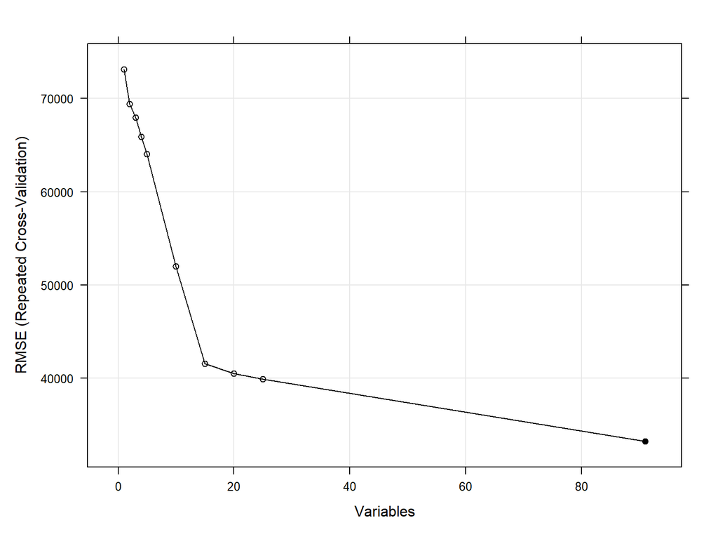

```r
# plot
trellis.par.set(caretTheme())
plot(lmProfile, type = c("g", "o"))
```

```r
ref_lm <- caret::predictors(lmProfile)[1:20]
```

Run the RFE algorithm on Random Forest model

```r
# customize a function to implement Random Forest in RFE algorithm
rfRFE <-  list(summary = defaultSummary,
               fit = function(x, y, first, last, ...){
                 library(randomForest)
                 randomForest(x, y, importance = first, ...)
                 },
               pred = function(object, x)  predict(object, x),
               rank = function(object, x, y) {
                 vimp <- varImp(object)
                 vimp <- vimp[order(vimp$Overall,decreasing = TRUE),,drop = FALSE]
                 vimp$var <- rownames(vimp)
                 vimp
                 },
               selectSize = pickSizeBest,
               selectVar = pickVars)


# change parameters in ctrl_rfe
ctrl_rfe$functions <- rfRFE  # random forest

ctrl_rfe$returnResamp <- "all"  # save all the re-sampling results across subset sizes

set.seed(123)

rfProfile <- rfe(predictors, # predictors candidates
                 dummies_train_missing$SalePrice,  # response variable
                 sizes = subsets,
                 rfeControl = ctrl_rfe)
rfProfile
```

```
##
## Recursive feature selection
##
## Outer resampling method: Cross-Validated (10 fold, repeated 5 times)
##
## Resampling performance over subset size:
##
##  Variables  RMSE Rsquared   MAE RMSESD RsquaredSD MAESD Selected
##          1 44909   0.6818 31001   5920    0.05504  2402
##          2 40599   0.7400 27844   5967    0.05455  2327
##          3 38442   0.7675 25779   6424    0.05614  2318
##          4 36499   0.7943 24111   6112    0.05267  2289
##          5 36190   0.8025 23389   6881    0.06207  2599
##         10 31805   0.8431 20023   7193    0.06276  2220
##         15 30685   0.8544 19086   6971    0.05751  2192
##         20 30108   0.8607 18613   6960    0.05618  2265
##         25 29988   0.8620 18438   6972    0.05564  2275        *
##         91 30025   0.8637 18296   7181    0.05347  2275
##
## The top 5 variables (out of 25):
##    OverallQual, X1stFlrSF, LotArea, GarageArea, TotRmsAbvGrd
```

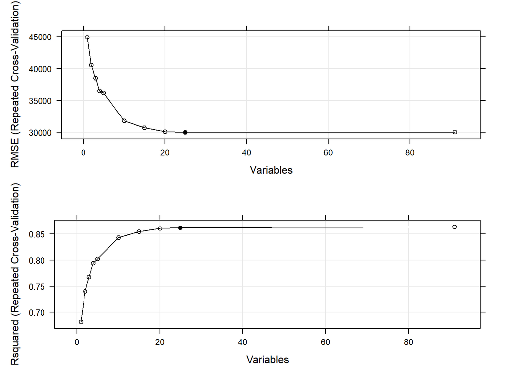

```r
# plot1 and 2
trellis.par.set(caretTheme())
plot1 <- plot(rfProfile, type = c("g", "o"))
plot2 <- plot(rfProfile, type = c("g", "o"), metric = "Rsquared")
print(plot1, split=c(1,1,1,2), more=TRUE)
print(plot2, split=c(1,2,1,2))
```

```r
# extract predictors
rfe_RF_var <- predictors(rfProfile)[1:15]

rfe_RF_var  # print variable names
```

```
##  [1] "OverallQual"  "X1stFlrSF"    "LotArea"      "GarageArea"   "TotRmsAbvGrd"
##  [6] "YearBuilt"    "BsmtFinSF1"   "FullBath_2"   "MSSubClass"   "GarageCars_3"
## [11] "GarageCars_2" "ExterQual_Gd" "YearRemodAdd" "HalfBath_1"   "CentralAir_Y"
```

There is an elbow around 15 variables. Then I pick top 15 variables to maintain RMSE or R-squared metrics.

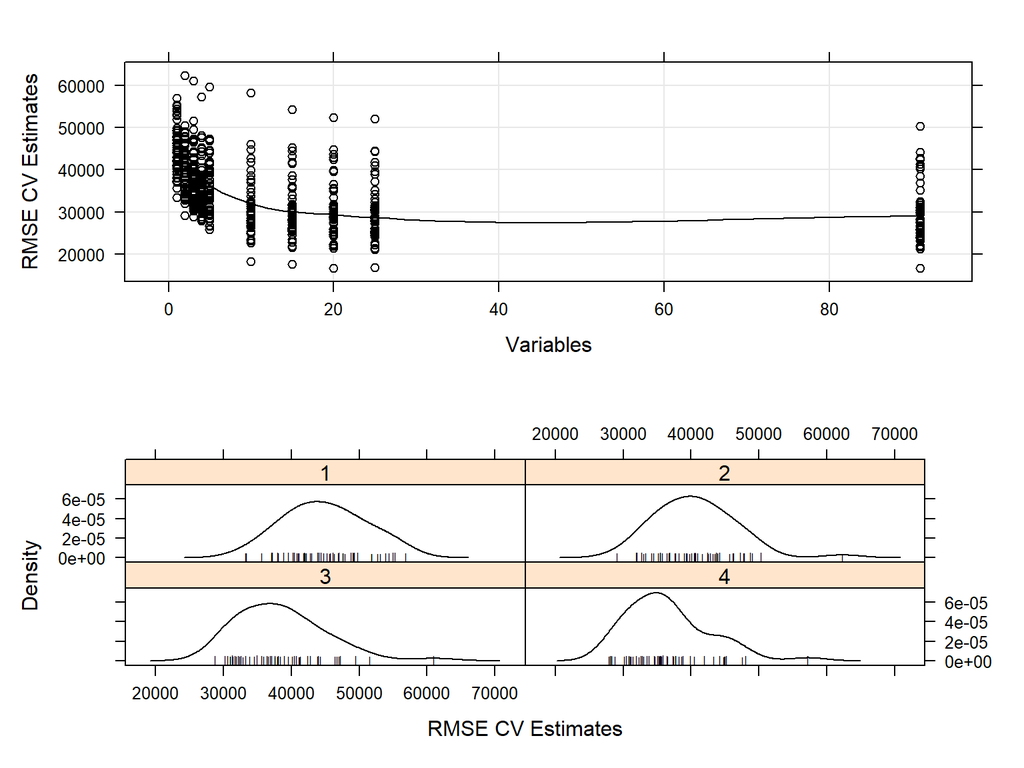

```r
# plot3 and 4
plot3 <- xyplot(rfProfile,
                type = c("g", "p", "smooth"),
                ylab = "RMSE CV Estimates")

plot4 <- densityplot(rfProfile,
                     subset = Variables < 5,
                     adjust = 1.25,
                     as.table = TRUE,
                     xlab = "RMSE CV Estimates",
                     pch = "|")
print(plot3, split=c(1,1,1,2), more=TRUE)
print(plot4, split=c(1,2,1,2))
```

### 0.3.12 Train models

Set up re-sampling method. Use [k-fold cross validation](https://rpubs.com/cliex159/881990) strategy.

```r
fitControl <- trainControl(method = "cv", # cross validation
                           number = 5,  # k = 5
                           verboseIter = TRUE)
```

```r
# features derived from the univariate analysis
top_univar
```

```
##  [1] "SalePrice"            "OverallQual"          "GarageArea"
##  [4] "GarageCars_3"         "X1stFlrSF"            "TotRmsAbvGrd"
##  [7] "YearBuilt"            "YearRemodAdd"         "ExterQual_Gd"
## [10] "FullBath_2"           "Neighborhood_NridgHt"
```

```r
# features derived from PCA
top_var_pca
```

```
##  [1] "YearBuilt"        "OverallQual"      "SalePrice"        "BsmtQual_TA"
##  [5] "YearRemodAdd"     "ExterQual_Gd"     "GarageArea"       "FullBath_2"
##  [9] "GarageFinish_Unf" "OverallCond_5"    "GarageCars_1"     "BsmtQual_Gd"
```

```r
# features derived from sbf - univariate filtering (the best variables for random forest)
sbf_vars
```

```
##  [1] "MSZoning_RL"          "LotShape_Reg"         "LotConfig_CulDSac"
##  [4] "LotConfig_Inside"     "Neighborhood_CollgCr" "Neighborhood_Edwards"
##  [7] "Neighborhood_NAmes"   "Neighborhood_NridgHt" "Neighborhood_OldTown"
## [10] "Neighborhood_Sawyer"  "Neighborhood_Somerst" "Condition1_Feedr"
## [13] "Condition1_Norm"      "HouseStyle_1Story"    "OverallCond_5"
## [16] "OverallCond_6"        "OverallCond_7"        "RoofStyle_Gable"
## [19] "Exterior1st_Wd.Sdng"  "Exterior2nd_HdBoard"  "Exterior2nd_MetalSd"
## [22] "Exterior2nd_VinylSd"  "MasVnrType_BrkFace"   "MasVnrType_None"
## [25] "MasVnrType_Stone"     "ExterQual_Gd"         "Foundation_CBlock"
## [28] "BsmtQual_Gd"          "BsmtQual_TA"          "BsmtCond_TA"
## [31] "BsmtExposure_Gd"      "BsmtExposure_Mn"      "BsmtExposure_No"
## [34] "BsmtFinType1_BLQ"     "BsmtFinType1_GLQ"     "BsmtFinType1_LwQ"
## [37] "BsmtFinType1_Rec"     "BsmtFinType1_Unf"     "BsmtFinType2_Unf"
## [40] "HeatingQC_Gd"         "HeatingQC_TA"         "CentralAir_Y"
## [43] "Electrical_SBrkr"     "BsmtFullBath_1"       "FullBath_2"
## [46] "HalfBath_1"           "BedroomAbvGr_2"       "BedroomAbvGr_4"
## [49] "KitchenQual_Gd"       "Functional_Typ"       "Fireplaces_1"
## [52] "Fireplaces_2"         "GarageType_Attchd"    "GarageType_BuiltIn"
## [55] "GarageType_Detchd"    "GarageFinish_RFn"     "GarageFinish_Unf"
## [58] "GarageCars_1"         "GarageCars_3"         "PavedDrive_Y"
## [61] "SaleType_WD"          "SaleCondition_Normal" "MSSubClass"
## [64] "LotFrontage"          "LotArea"              "OverallQual"
## [67] "YearBuilt"            "YearRemodAdd"         "MasVnrArea"
## [70] "BsmtFinSF1"           "BsmtUnfSF"            "X1stFlrSF"
## [73] "TotRmsAbvGrd"         "GarageYrBlt"          "GarageArea"
## [76] "WoodDeckSF"           "OpenPorchSF"
```

```r
# features derived from REF-linear regression
ref_lm
```

```
##  [1] "GarageCars_1"         "GarageCars_2"         "Fireplaces_2"
##  [4] "MasVnrType_None"      "GarageType_BuiltIn"   "Neighborhood_NridgHt"
##  [7] "Neighborhood_Edwards" "BsmtExposure_Gd"      "BsmtQual_TA"
## [10] "BsmtQual_Gd"          "OverallQual"          "GarageType_Detchd"
## [13] "GarageType_Attchd"    "Neighborhood_NAmes"   "Neighborhood_Somerst"
## [16] "HalfBath_1"           "HouseStyle_1Story"    "Functional_Typ"
## [19] "Neighborhood_Gilbert" "Condition1_Norm"
```

```r
# features derived from REF-Random Forest
rfe_RF_var
```

```
##  [1] "OverallQual"  "X1stFlrSF"    "LotArea"      "GarageArea"   "TotRmsAbvGrd"
##  [6] "YearBuilt"    "BsmtFinSF1"   "FullBath_2"   "MSSubClass"   "GarageCars_3"
## [11] "GarageCars_2" "ExterQual_Gd" "YearRemodAdd" "HalfBath_1"   "CentralAir_Y"
```

```r
# subset important features from train set
dummies_train_missing2 <-
  dummies_train_missing %>%
  select(all_of(sbf_vars), SalePrice)

# deal with missing values
dummies_train_missing3 <- dummies_train_missing2 %>% replace(is.na(.), 0)

head(dummies_train_missing3)
```

|  | MSZoning_RL | LotShape_Reg | LotConfig_CulDSac | LotConfig_Inside | Neighborhood_CollgCr | Neighborhood_Edwards | Neighborhood_NAmes | Neighborhood_NridgHt | Neighborhood_OldTown | Neighborhood_Sawyer | Neighborhood_Somerst | Condition1_Feedr | Condition1_Norm | HouseStyle_1Story | OverallCond_5 | OverallCond_6 | OverallCond_7 | RoofStyle_Gable | Exterior1st_Wd.Sdng | Exterior2nd_HdBoard | Exterior2nd_MetalSd | Exterior2nd_VinylSd | MasVnrType_BrkFace | MasVnrType_None | MasVnrType_Stone | ExterQual_Gd | Foundation_CBlock | BsmtQual_Gd | BsmtQual_TA | … |
| --- | --- | --- | --- | --- | --- | --- | --- | --- | --- | --- | --- | --- | --- | --- | --- | --- | --- | --- | --- | --- | --- | --- | --- | --- | --- | --- | --- | --- | --- | --- |
| W1 | 1 | 1 | 0 | 1 | 1 | 0 | 0 | 0 | 0 | 0 | 0 | 0 | 1 | 0 | 1 | 0 | 0 | 1 | 0 | 0 | 0 | 1 | 1 | 0 | 0 | 1 | 0 | 1 | 0 | … |
| W2 | 1 | 1 | 0 | 0 | 0 | 0 | 0 | 0 | 0 | 0 | 0 | 1 | 0 | 1 | 0 | 0 | 0 | 1 | 0 | 0 | 1 | 0 | 0 | 1 | 0 | 0 | 1 | 1 | 0 | … |
| W3 | 1 | 0 | 0 | 1 | 1 | 0 | 0 | 0 | 0 | 0 | 0 | 0 | 1 | 0 | 1 | 0 | 0 | 1 | 0 | 0 | 0 | 1 | 1 | 0 | 0 | 1 | 0 | 1 | 0 | … |
| W4 | 1 | 0 | 0 | 0 | 0 | 0 | 0 | 0 | 0 | 0 | 0 | 0 | 1 | 0 | 1 | 0 | 0 | 1 | 1 | 0 | 0 | 0 | 0 | 1 | 0 | 0 | 0 | 0 | 1 | … |
| W5 | 1 | 0 | 0 | 0 | 0 | 0 | 0 | 0 | 0 | 0 | 0 | 0 | 1 | 0 | 1 | 0 | 0 | 1 | 0 | 0 | 0 | 1 | 1 | 0 | 0 | 1 | 0 | 1 | 0 | … |
| W6 | 1 | 0 | 0 | 1 | 0 | 0 | 0 | 0 | 0 | 0 | 0 | 0 | 1 | 0 | 1 | 0 | 0 | 1 | 0 | 0 | 0 | 1 | 0 | 1 | 0 | 0 | 0 | 1 | 0 | … |

#### 0.3.12.1 Pick algorithms

Select the most diverse ML algorithms, using maximum dissimilarity sampling. Follow the codes and data in the [caret tutorial](https://topepo.github.io/caret/models-clustered-by-tag-similarity.html)

```r
# Import the survey data containing model tags
tag <- read.csv("tag_data.csv", row.names = 1)
tag <- as.matrix(tag)


# Select only models for regression
regModels <- tag[tag[,"Regression"] == 1,]

all <- 1:nrow(regModels)

# Seed the analysis with the generalized linear model
start <- grep("(rf)", rownames(regModels), fixed = TRUE)
pool <- all[all != start]

## Select 4 model models by maximizing the Jaccard
## dissimilarity between sets of models
nextMods <- maxDissim(regModels[start,,drop = FALSE],
                      regModels[pool, ],
                      method = "Jaccard",
                      n = 4)

rownames(regModels)[c(start, nextMods)]
```

```
## [1] "Random Forest (rf)"
## [2] "Ridge Regression with Variable Selection (foba)"
## [3] "Relevance Vector Machines with Linear Kernel (rvmLinear)"
## [4] "Bayesian Regularized Neural Networks (brnn)"
## [5] "Negative Binomial Generalized Linear Model (glm.nb)"
```

```r
set.seed(123)  # ensure reproducibility


# Negative Binomial Generalized Linear Model
glm_train <- train(SalePrice ~ .,
                   data = dummies_train_missing3,
                   method = "glm.nb",
                   trControl = fitControl)

glm_train # train model



# Ridge Regression with Variable Selection
foba_train <- train(SalePrice ~ .,
                   data = dummies_train_missing3,
                   method = "foba",
                   trControl = fitControl)

foba_train



# Relevance Vector Machines with Linear Kernel
# rvmLinear_train <- train(SalePrice ~ .,
#                    data = dummies_train_missing3,
#                    method = "rvmLinear",
#                    trControl = fitControl)
#
# rvmLinear_train



# Bayesian Regularized Neural Networks
brnn_train <- train(SalePrice ~ .,
                   data = dummies_train_missing3,
                   method = "brnn",
                   trControl = fitControl)

brnn_train



# Linear regression
lm_train <- train(SalePrice ~ .,
                   data = dummies_train_missing3,
                   method = "lm",
                   trControl = fitControl)

lm_train  # model info



# GAM
gam_train <- train(SalePrice ~ .,
                   data = dummies_train_missing3,
                   method = "gam",
                   trControl = fitControl)

gam_train # model information



# Random forest
rf_train <- train(SalePrice ~ .,
                   data = dummies_train_missing3,
                   method = "rf",
                   trControl = fitControl)

rf_train # model information


# eXtreme Gradient boosting   - takes very long time to run
# xgb_train <- train(SalePrice ~ .,
#                    data = dummies_train_missing3,
#                    method = "xgbDART",
#                    trControl = fitControl)
#
# xgb_train # model information
```

### 0.3.13 Graphically evaluate models

Use different plots to evaluate models, - Prediction vs. ground truth plot - Residual plot - Gain curve

```r
# copy the train set
dummies_train_missing4 <- dummies_train_missing3

# prediction on train set with 4 models
dummies_train_missing4$pred_lm <- predict(lm_train) # lm
dummies_train_missing4$pred_glm <- predict(glm_train) # glm
dummies_train_missing4$pred_gam <- predict(gam_train)  # gam
dummies_train_missing4$pred_rf <- predict(rf_train)  # rf
dummies_train_missing4$pred_foba <- predict(foba_train)  # foba
dummies_train_missing4$pred_brnn <- predict(brnn_train)  # brnn


# calculate residuals
dummies_train_missing4 <- dummies_train_missing4 %>%
  mutate(residual_lm = pred_lm - SalePrice) %>%
  mutate(residual_glm = pred_glm - SalePrice) %>%
  mutate(residual_gam = pred_gam - SalePrice) %>%
  mutate(residual_rf = pred_rf - SalePrice) %>%
  mutate(residual_foba = pred_foba - SalePrice) %>%
  mutate(residual_brnn = pred_brnn - SalePrice)
```

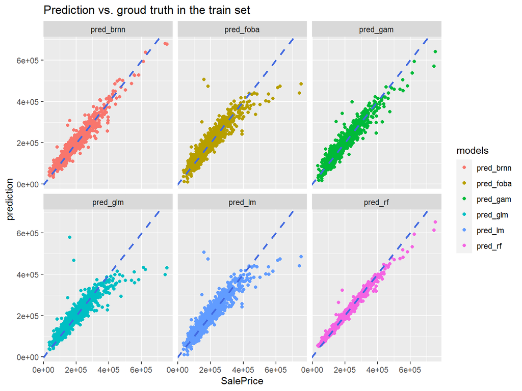

```r
# prediction vs. truth plots
pred_truth_df <- dummies_train_missing4 %>%
  select(pred_lm, pred_glm, pred_gam, pred_rf, pred_foba, pred_brnn, SalePrice) %>%
  gather(key = "models", value = "prediction", -SalePrice)
ggplot(pred_truth_df, aes(x= SalePrice, y= prediction, color = models)) +
  geom_point() +
  geom_abline(slope = 1, intercept = 0,
              linetype = "dashed", color = "royalblue", linewidth = 1)+
  facet_wrap(vars(models)) +
  ggtitle("Prediction vs. groud truth in the train set")
```

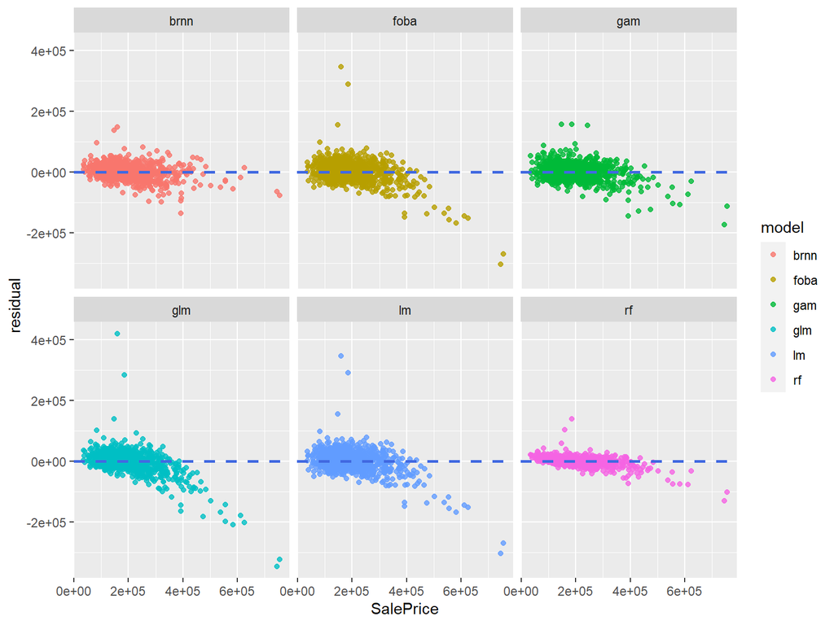

```r
# residual plot
res_truth_df <- dummies_train_missing4 %>%
  select(residual_lm, residual_glm, residual_gam, residual_rf, residual_foba, residual_brnn, SalePrice) %>%
  gather(key = "models", value = "residual", -SalePrice) %>%
  mutate(model = str_sub(.$models, start = 10)) %>%
  select(-models)
ggplot(res_truth_df, aes(x=SalePrice, y= residual, color = model))+
  geom_point(alpha = 0.8) +
  geom_hline(yintercept = 0,
             linetype = "dashed", color = "royalblue", size = 1) +
  facet_wrap(vars(model))
```

Draw the gain curves using `WVPlots` [package](https://www.rdocumentation.org/packages/WVPlots/versions/1.3.2/topics/GainCurvePlot). The data camp course, “Supervised machine learning regression” explains the gain curves in more detailed.

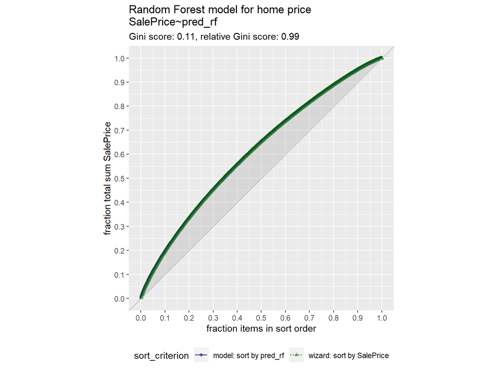

```r
# random forest - gain curve
GainCurvePlot(dummies_train_missing4,
              "pred_rf",
              "SalePrice",
              "Random Forest model for home price")
```

In the gain curve, the x-axis is sale prices in model-sorted order (decreasing). The y-axis is the fraction of total accumulatd sale price. The wizard curve represents the perfect model.

### 0.3.14 Select the best model

Apply `postResample` function in caret package to estimate measures of model performance, including

- RMSE * (Kaggle evaluation metric)
- Rsquared
- MAE

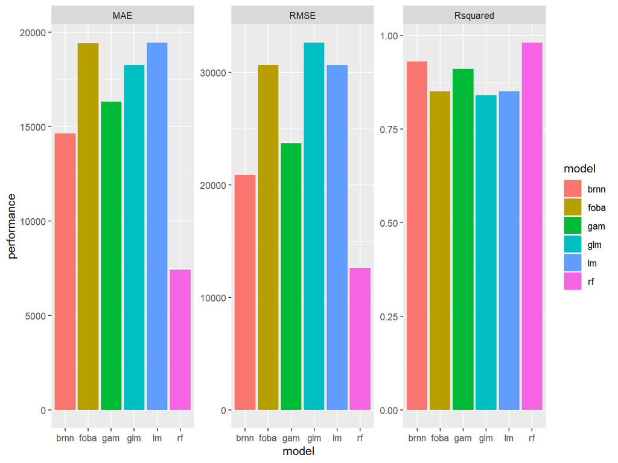

```r
rf_perf <- postResample(pred = dummies_train_missing4$pred_rf, obs = dummies_train_missing4$SalePrice) %>% as.data.frame() # rf

lm_perf <- postResample(pred = dummies_train_missing4$pred_lm, obs = dummies_train_missing4$SalePrice) %>% as.data.frame() # lm

gam_perf <-  postResample(pred = dummies_train_missing4$pred_gam, obs = dummies_train_missing4$SalePrice) %>% as.data.frame()  # gam

glm_perf <-  postResample(pred = dummies_train_missing4$pred_glm, obs = dummies_train_missing4$SalePrice) %>% as.data.frame() # glm

foba_perf <- postResample(pred = dummies_train_missing4$pred_foba, obs = dummies_train_missing4$SalePrice) %>% as.data.frame() # foba

brnn_perf <- postResample(pred = dummies_train_missing4$pred_brnn, obs = dummies_train_missing4$SalePrice) %>% as.data.frame() # brnn


# merge above data frames
merg_perf <- data.frame(rf = rf_perf,
                        lm = lm_perf,
                        gam = gam_perf,
                        glm = glm_perf,
                        brnn = brnn_perf,
                        foba = foba_perf)

colnames(merg_perf) <- c("rf", "lm", "gam", "glm", "brnn", "foba")  # rename columns

merg_perf <- merg_perf %>%
  rownames_to_column("measure")  # row to column

merg_perf <- merg_perf %>%
  gather(key = "model", value = "performance", -measure) %>%
  mutate(performance = round(performance, 2))

# bar plot to compare single value by measures
ggplot(merg_perf, aes(x = model, y = performance)) +
  geom_bar(aes(fill = model), stat = "identity", position = "dodge") +
  facet_wrap(vars(measure), scales = "free_y")
```

The random forest model outperforms counterparts based on three performance measures. Thus pick the random forest model to predict test set.

### 0.3.15 Preprocess the test set

```r
# convert character variables to factor variables
test_df2 <- test_df %>%
        mutate_if(is.character, as.factor) %>%
        mutate(Id = paste("W", as.character(Id), sep = "")) %>%  # keep id as character variables
        column_to_rownames("Id")

# numeric variables
test_df_num <- test_df2[ ,is_num_var2]

# convert character variables to factors
test_df_fact  <- test_df2 %>%
  dplyr::select(all_of(is_fact_var)) %>%   # subset 54 non-numeric variables and a response variable
  mutate_all(., as.factor) # convert character variables to factors

# combine numeric variables and factors
test_df_comb <- cbind(test_df_fact, test_df_num)




# double-check if any factor only has one level
factor_test <- sapply(test_df_comb, function(x) length(levels(x))) %>%
  as.data.frame() %>%
  rownames_to_column("variable")

colnames(factor_test) <- c("variable", "level")

factor_test %>%
  filter(level == 1) %>%
  pull(variable)
```

```
## [1] "Utilities"
```

```r
# drop the factor, 'Utilities'
test_df_comb2 <- test_df_comb %>%
  select(-Utilities)



# create dummy variables
dummy_test <- dummyVars(~., data = test_df_comb2,
                           fullRank = TRUE,
                           sep = "_")

dummy_test_df <- data.frame(predict(dummy_test,
                                    newdata = test_df_comb2))
```

### 0.3.16 Predict the test set

```r
# extract the final model of Random forest
rf_train_finalmod <- rf_train$finalModel

# replace missing values in the test set with 0
dummy_test_df_rm.na <- dummy_test_df %>% replace(is.na(.), 0)

# predict on the test set
dummy_test_df_rm.na$SalePrice_pred <- predict(rf_train_finalmod,  # optimal Random Forest model
                                              dummy_test_df_rm.na)  # test set with replacing NAs



# export final results based on test set
head(dummy_test_df_rm.na)
```

|  | MSZoning_FV | MSZoning_RH | MSZoning_RL | MSZoning_RM | Street_Pave | Alley_Pave | LotShape_IR2 | LotShape_IR3 | LotShape_Reg | LandContour_HLS | LandContour_Low | LandContour_Lvl | LotConfig_CulDSac | LotConfig_FR2 | LotConfig_FR3 | LotConfig_Inside | LandSlope_Mod | LandSlope_Sev | Neighborhood_Blueste | Neighborhood_BrDale | Neighborhood_BrkSide | Neighborhood_ClearCr | Neighborhood_CollgCr | Neighborhood_Crawfor | Neighborhood_Edwards | Neighborhood_Gilbert | Neighborhood_IDOTRR | Neighborhood_MeadowV | Neighborhood_Mitchel | … |
| --- | --- | --- | --- | --- | --- | --- | --- | --- | --- | --- | --- | --- | --- | --- | --- | --- | --- | --- | --- | --- | --- | --- | --- | --- | --- | --- | --- | --- | --- | --- |
| W1461 | 0 | 1 | 0 | 0 | 1 | 0 | 0 | 0 | 1 | 0 | 0 | 1 | 0 | 0 | 0 | 1 | 0 | 0 | 0 | 0 | 0 | 0 | 0 | 0 | 0 | 0 | 0 | 0 | 0 | … |
| W1462 | 0 | 0 | 1 | 0 | 1 | 0 | 0 | 0 | 0 | 0 | 0 | 1 | 0 | 0 | 0 | 0 | 0 | 0 | 0 | 0 | 0 | 0 | 0 | 0 | 0 | 0 | 0 | 0 | 0 | … |
| W1463 | 0 | 0 | 1 | 0 | 1 | 0 | 0 | 0 | 0 | 0 | 0 | 1 | 0 | 0 | 0 | 1 | 0 | 0 | 0 | 0 | 0 | 0 | 0 | 0 | 0 | 1 | 0 | 0 | 0 | … |
| W1464 | 0 | 0 | 1 | 0 | 1 | 0 | 0 | 0 | 0 | 0 | 0 | 1 | 0 | 0 | 0 | 1 | 0 | 0 | 0 | 0 | 0 | 0 | 0 | 0 | 0 | 1 | 0 | 0 | 0 | … |
| W1465 | 0 | 0 | 1 | 0 | 1 | 0 | 0 | 0 | 0 | 1 | 0 | 0 | 0 | 0 | 0 | 1 | 0 | 0 | 0 | 0 | 0 | 0 | 0 | 0 | 0 | 0 | 0 | 0 | 0 | … |
| W1466 | 0 | 0 | 1 | 0 | 1 | 0 | 0 | 0 | 0 | 0 | 0 | 1 | 0 | 0 | 0 | 0 | 0 | 0 | 0 | 0 | 0 | 0 | 0 | 0 | 0 | 1 | 0 | 0 | 0 | … |

```r
submission_pred <- dummy_test_df_rm.na %>%
  rownames_to_column("Id") %>%
  select(Id, SalePrice = SalePrice_pred) %>%
  mutate(Id = str_sub(Id, start=2)) %>%
  mutate(SalePrice = round(SalePrice, 4))  # round to 4 decimal point

write.csv(submission_pred,
          file = "submission_davidxzhao.csv",
          row.names = F,  # without row labels
          quote = F) # without quote
```

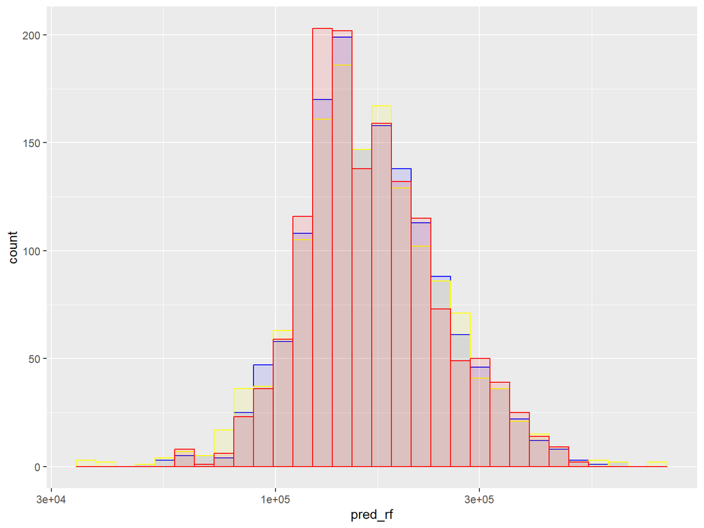

```r
# histogram plots
dummies_train_missing4 %>%
  ggplot(aes(x= pred_rf))+
  geom_histogram(color = "blue", fill="blue", alpha = 0.1) +  # prediction in train set
  geom_histogram(aes(x = SalePrice), color = "yellow", fill= "yellow", alpha = 0.1) +  # truth in train set
  geom_histogram(data = dummy_test_df_rm.na, # prediction in test set
                 aes(x = SalePrice_pred),
                 color = "red", fill="red", alpha = 0.1) +
  scale_x_log10()  # log10 scale
```

#### 0.3.16.1 Feature importance based on Random Forest model

Which features are most predictive? Use `varImp` function in the `caret` package to estimate variable ranking in either model-dependent and model-independent metrics.

The [tutorial](https://topepo.github.io/caret/variable-importance.html) of caret package provides detailed explanation for `varImp` function.

```r
# Random Forest dependent metrics
rfImp <- varImp(rf_train,
                scale = T, # scale = F, avoids normalization
                useModel = T)

# alternatively, model independent metrics
variable_Imp  <- varImp(rf_train,
                        scale = T, # scale = F, avoids normalization
                        useModel = FALSE)  # non-specific


# # plot with base R
# plot(rfImp, top = 10)
```

Visualize variable rankings based on two metrics using `ggplot2`.

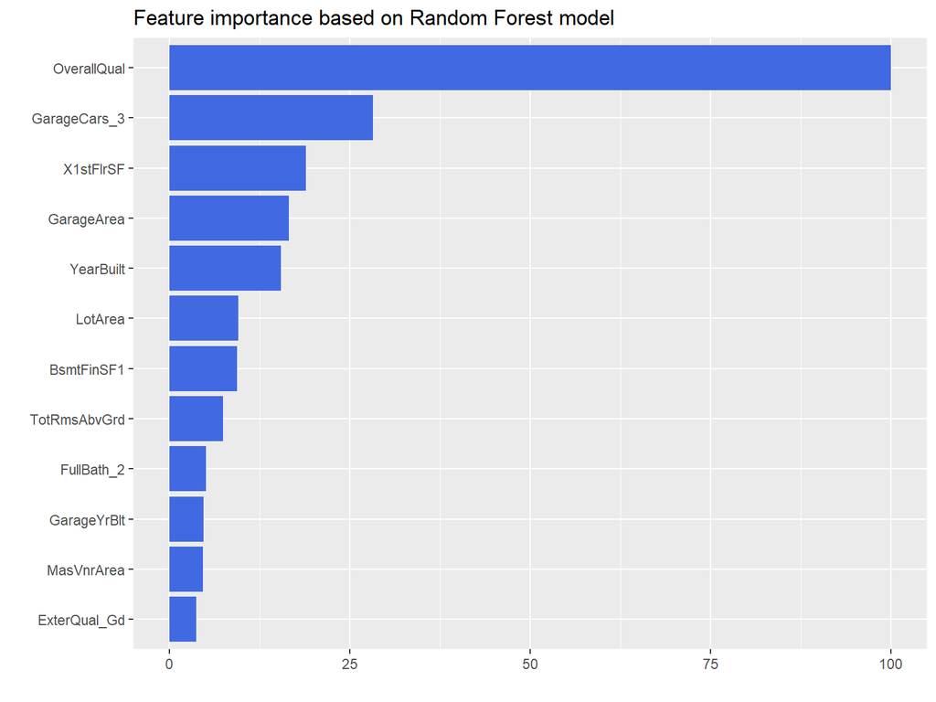

```r
# bar plot
rfImp_df <- rfImp$importance %>%
  rownames_to_column("variable")

rfImp_df %>%
  arrange(desc(Overall)) %>%
  head(12) %>%
  ggplot(aes(y=Overall, x=reorder(variable, Overall))) +
  geom_bar(stat = "identity", fill = "royalblue") +
  coord_flip() +
  ggtitle("Feature importance based on Random Forest model") +
  labs(x = "", y="")
```

Detailed information for each variables: - `OverllQual`: Overall material and finish quality - `X1stFlrSF`: unknown - `GarageCars_3`: Size of garage in car capacity - `GarageArea`: Size of garage in square feet - `YearBuilt`: Original construction date - `TotRmsAbvGrd`: Total rooms above grade (does not include bathrooms) - `YearRemodAdd`: Remodel date